# Resum - Mineria de dades

Moisès Gil i Bernabeu

# Preparació de dades

1. Importació del banc de dades, diferent segons origen.
2. Revisió de l’estructura del banc de dades. Filera (individus) per columna (variables).
3. Estudiar el banc de dades per conéixer’l. Què expressen les variables, tipus de variables és adequat, modificar si no estan contemplats els factors.
4. Revisió del nom de fileres i columnes.

# Anàlisi exploratòria de dades

## Descriptiva numèrica

### Univariant

L’apply funciona amb marges `1` per a les fileres i `2` per a les columnes, per a aplicar funcions sobre les variables, cal emprar `2`.

**Skewnes** és l’asimetria:

- Skewness = 0 (simètrica)
- Skewness > 0 (asimètrica, cua llarga a la dreta)
- Skewness < 0 (asimètrica, cua llarga a l’esquerra)

**Kurtosis** és l’apuntament:

- Kurtosis = 0 (apuntament d’una normal)
- Kurtosis > 0 (més apuntament que la normal)
- Kurtosis < 0 (menys apuntament que la normal)

```r
library(e1071)
data(airquality)
data <- airquality
str(data)
```

```
## 'data.frame':    153 obs. of  6 variables:
##  $ Ozone  : int  41 36 12 18 NA 28 23 19 8 NA ...
##  $ Solar.R: int  190 118 149 313 NA NA 299 99 19 194 ...
##  $ Wind   : num  7.4 8 12.6 11.5 14.3 14.9 8.6 13.8 20.1 8.6 ...
##  $ Temp   : int  67 72 74 62 56 66 65 59 61 69 ...
##  $ Month  : int  5 5 5 5 5 5 5 5 5 5 ...
##  $ Day    : int  1 2 3 4 5 6 7 8 9 10 ...
```

```r
count.na <- function(x) {
  c(Min = min(x, na.rm = TRUE), Max = max(x, na.rm = TRUE),
    q = quantile(x, 0.25, na.rm = TRUE), Mediana = median(x, na.rm = TRUE),
    q = quantile(x, 0.75, na.rm = TRUE), Mean = mean(x, na.rm = TRUE),
    Var = var(x, na.rm = TRUE), SD = sd(x, na.rm = TRUE),
    Skewness = skewness(x, na.rm = TRUE), Kurtosis = kurtosis(x, na.rm = TRUE),
    NAs = sum(is.na(x)))
}

sum.table <- t(apply(data, 2, count.na))

kable(sum.table, digits = 3, booktabs = T) %>%
      kable_styling(latex_options =c('hold_position', 'striped'))
```

|  | Min | Max | q.25% | Mediana | q.75% | Mean | Var | SD | Skewness | Kurtosis | NAs |
| --- | --- | --- | --- | --- | --- | --- | --- | --- | --- | --- | --- |
| Ozone | 1.0 | 168.0 | 18.00 | 31.5 | 63.25 | 42.129 | 1088.201 | 32.988 | 1.210 | 1.112 | 37 |
| Solar.R | 7.0 | 334.0 | 115.75 | 205.0 | 258.75 | 185.932 | 8110.519 | 90.058 | -0.419 | -1.004 | 7 |
| Wind | 1.7 | 20.7 | 7.40 | 9.7 | 11.50 | 9.958 | 12.412 | 3.523 | 0.341 | 0.029 | 0 |
| Temp | 56.0 | 97.0 | 72.00 | 79.0 | 85.00 | 77.882 | 89.591 | 9.465 | -0.371 | -0.463 | 0 |
| Month | 5.0 | 9.0 | 6.00 | 7.0 | 8.00 | 6.993 | 2.007 | 1.417 | -0.002 | -1.317 | 0 |
| Day | 1.0 | 31.0 | 8.00 | 16.0 | 23.00 | 15.804 | 78.580 | 8.865 | 0.003 | -1.222 | 0 |

### Multivariant

Matriu de variàncies-covariàncies `cov`, relació lineal entre variables, la diagonal recull la variància de cadascuna de les variables, la resta d’elements mostren la covariància (mesura de la variabilitat conjunta) entre cada parell de variables.

```r
load('../practiques/practica_04/classe/medifis.RData')
data <- medifis
cov(data)
```

```
##           sex        est        pes       pie       lbr       aes        dcr
## sex 0.2564103   4.064103   4.782051  1.239316  1.978632  1.452991  0.3504274
## est 4.0641026 103.948718 108.358974 27.091880 45.856838 34.427350 11.0363248
## pes 4.7820513 108.358974 163.871795 31.151709 52.053419 43.213675 14.6047009
## pie 1.2393162  27.091880  31.151709  8.201567 12.095442  9.189459  2.8892450
## lbr 1.9786325  45.856838  52.053419 12.095442 24.575499 15.975071  4.3361823
## aes 1.4529915  34.427350  43.213675  9.189459 15.975071 16.169516  4.6428063
## dcr 0.3504274  11.036325  14.604701  2.889245  4.336182  4.642806  3.3917379
## lrt 1.1688034  27.155983  29.029915  7.694088 11.974715  8.004630  3.2268519
##           lrt
## sex  1.168803
## est 27.155983
## pes 29.029915
## pie  7.694088
## lbr 11.974715
## aes  8.004630
## dcr  3.226852
## lrt  9.962251
```

La matriu de correlacions mostra la relació lineal entre les variables. La diagonal pren valors d’1, ja que com són dos vectors iguals, la correlació entre ells és 1.

```r
cor(data)
```

```
##           sex       est       pes       pie       lbr       aes       dcr
## sex 1.0000000 0.7872042 0.7377249 0.8546062 0.7882179 0.7135869 0.3757674
## est 0.7872042 1.0000000 0.8302392 0.9278572 0.9072842 0.8397413 0.5877651
## pes 0.7377249 0.8302392 1.0000000 0.8497308 0.8202495 0.8394998 0.6194830
## pie 0.8546062 0.9278572 0.8497308 1.0000000 0.8519658 0.7979818 0.5478035
## lbr 0.7882179 0.9072842 0.8202495 0.8519658 1.0000000 0.8013885 0.4749471
## aes 0.7135869 0.8397413 0.8394998 0.7979818 0.8013885 1.0000000 0.6269327
## dcr 0.3757674 0.5877651 0.6194830 0.5478035 0.4749471 0.6269327 1.0000000
## lrt 0.7312991 0.8438733 0.7184804 0.8511969 0.7653063 0.6306872 0.5551229
##           lrt
## sex 0.7312991
## est 0.8438733
## pes 0.7184804
## pie 0.8511969
## lbr 0.7653063
## aes 0.6306872
## dcr 0.5551229
## lrt 1.0000000
```

Per al p-valor de la correlació.

```r
library(Hmisc)
rcorr(as.matrix(data))
```

```
##      sex  est  pes  pie  lbr  aes  dcr  lrt
## sex 1.00 0.79 0.74 0.85 0.79 0.71 0.38 0.73
## est 0.79 1.00 0.83 0.93 0.91 0.84 0.59 0.84
## pes 0.74 0.83 1.00 0.85 0.82 0.84 0.62 0.72
## pie 0.85 0.93 0.85 1.00 0.85 0.80 0.55 0.85
## lbr 0.79 0.91 0.82 0.85 1.00 0.80 0.47 0.77
## aes 0.71 0.84 0.84 0.80 0.80 1.00 0.63 0.63
## dcr 0.38 0.59 0.62 0.55 0.47 0.63 1.00 0.56
## lrt 0.73 0.84 0.72 0.85 0.77 0.63 0.56 1.00
##
## n= 27
##
##
## P
##     sex    est    pes    pie    lbr    aes    dcr    lrt
## sex        0.0000 0.0000 0.0000 0.0000 0.0000 0.0534 0.0000
## est 0.0000        0.0000 0.0000 0.0000 0.0000 0.0013 0.0000
## pes 0.0000 0.0000        0.0000 0.0000 0.0000 0.0006 0.0000
## pie 0.0000 0.0000 0.0000        0.0000 0.0000 0.0031 0.0000
## lbr 0.0000 0.0000 0.0000 0.0000        0.0000 0.0123 0.0000
## aes 0.0000 0.0000 0.0000 0.0000 0.0000        0.0005 0.0004
## dcr 0.0534 0.0013 0.0006 0.0031 0.0123 0.0005        0.0027
## lrt 0.0000 0.0000 0.0000 0.0000 0.0000 0.0004 0.0027
```

## Descriptiva gràfica

### Univariant

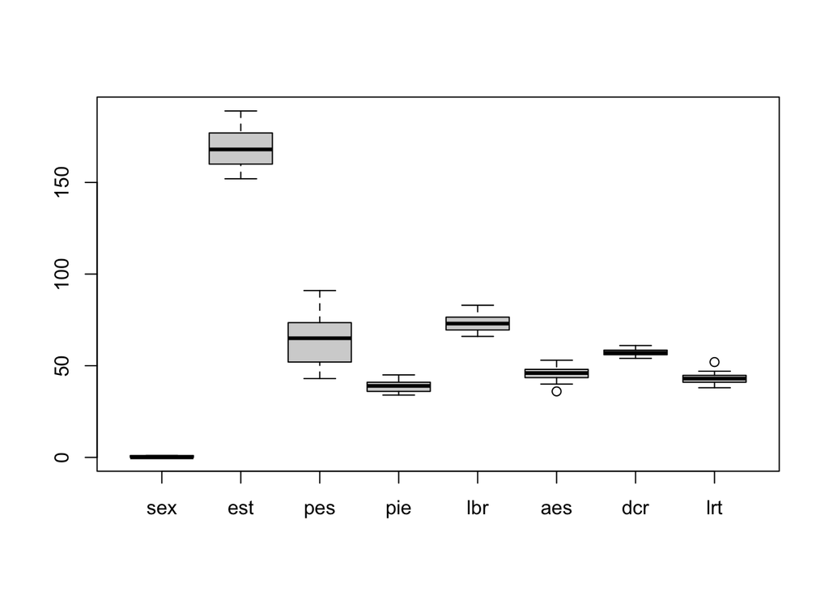

```r
boxplot(data)
```

Veient els boxplots pots plantejar-te si has d’estandarditzar les dades. Ho farem en dos casos: variàncies molt diferents (si no ens interessa que aquesta variable pese més en anàlisis com la de PCA o càlcul de distàncies –gran variància es tradueix en major importància en aquestes anàlisis–) o canvis d’unitats en què no es reflecteix la possible relació. No es recomana estandarditzar si no hi ha canvi en l’escala de les variables, ja que perds el significat de la variabilitat, però si hi ha canvis en l’escala depéns de les variables que tenen valors més grans que pot ser no reflectisca la realitat. La distància de Mahalanobis no queda afectada per l’estandardització.

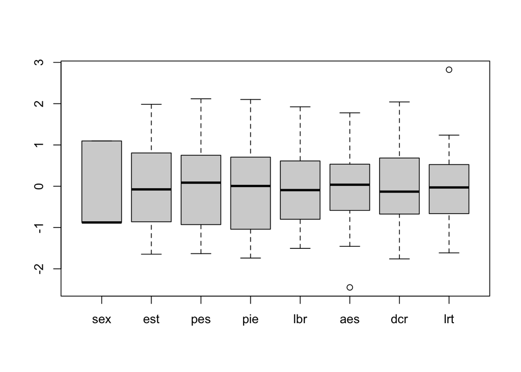

```r
sdata <- scale(data)
boxplot(sdata)
```

## Multivariant

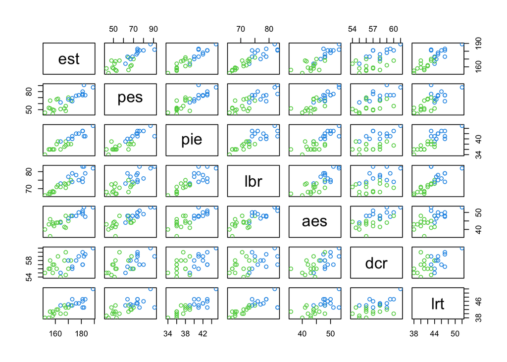

```r
plot(data[, -1], col = 3 + data[,1]) # 3 + per a començar en un color != 0
```

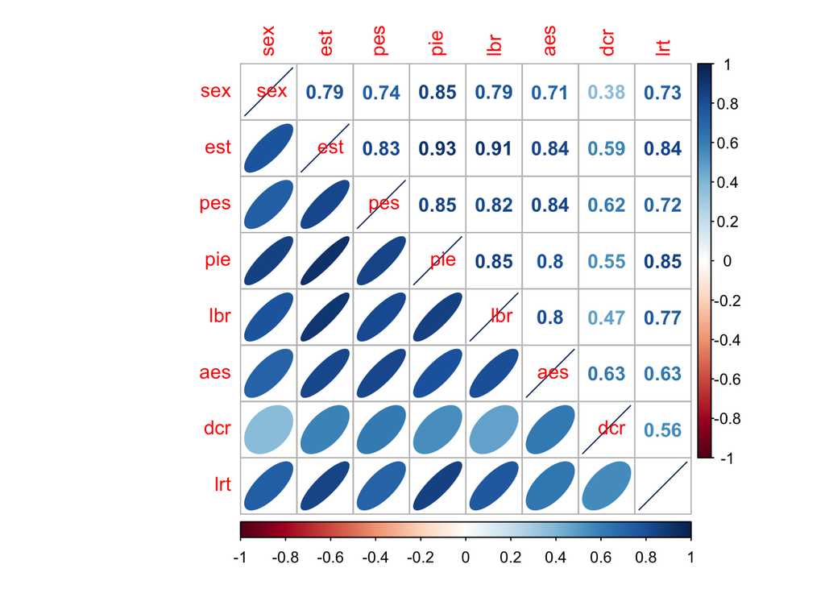

```r
library(corrplot)
matcor <- cor(data)
corrplot(matcor, method = 'ellipse', type = 'lower', diag = TRUE)
corrplot(matcor, method = 'number', type = 'upper', diag = FALSE, add = TRUE)
```

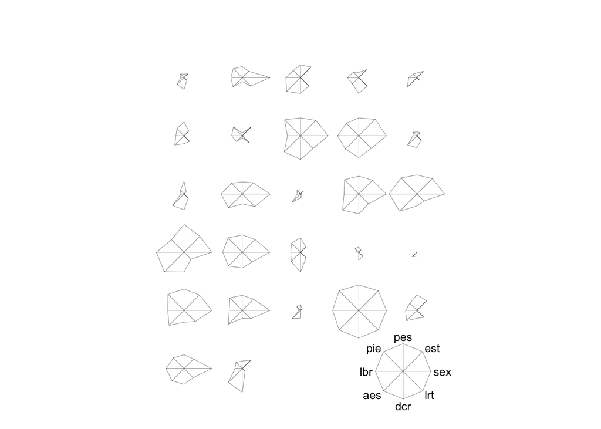

```r
stars(data, key.loc = c(10, 2))
```

## Outliers

La distància de Mahalanobis assumeix normalitat multivariant i dades contínues.

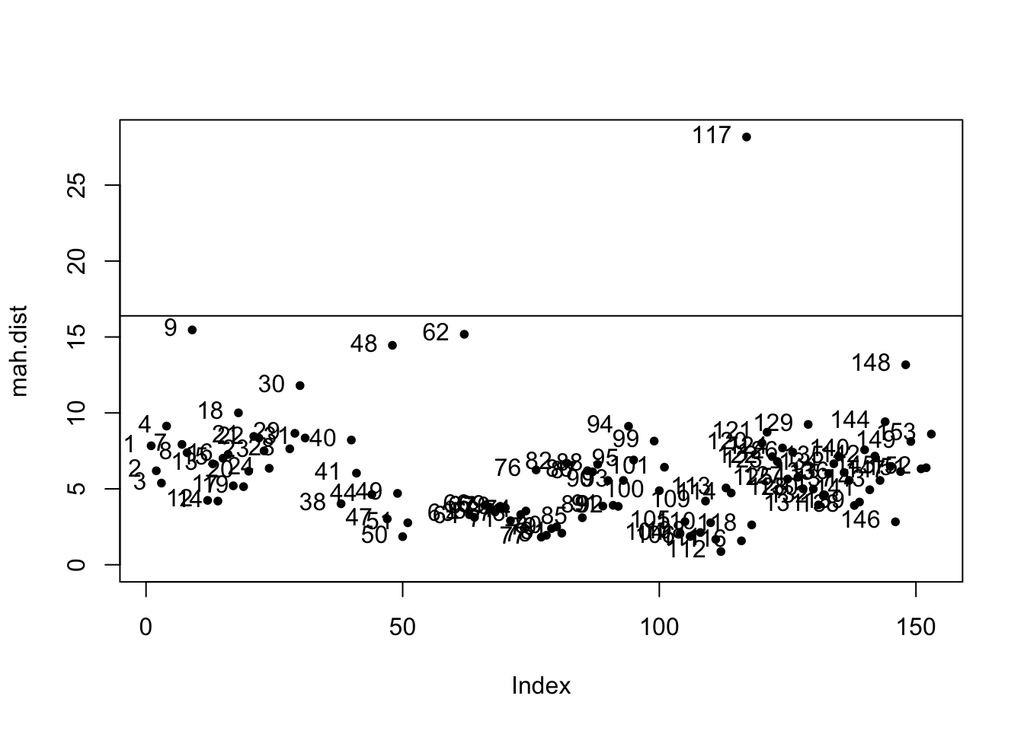

```r
data <- airquality
mah.dist <- mahalanobis(data, apply(data, 2, mean, na.rm = TRUE),
                        cov(data, use = 'na.or.complete'))
k <- dim(data)[2]
mah.lim <- k + 3 * sqrt(k * 2)
plot(mah.dist, pch = 20, ylim = c(0, max(mah.dist, mah.lim, na.rm = TRUE)))
text(mah.dist, labels = rownames(data), pos = 2)
abline(h = mah.lim)
```

## Dades faltants

Tipus:

- MCAR (pèrdua completament aleatòria) l’absència no depén de valors absents ni no-absents
- MAR (missing at random) la pèrdua d’una dada ´a una variable depén d’altra variable.
- NMAR (no missing at random) la pèrdua depén del valor de la variable (no tindre valor és informatiu).

Solucions:

- Eliminar les observacions.
- Eliminar variables que tenen molts `NA`.
- Imputació

### Imputació

**Simple**. Substituir la dada faltant per una estimació de tipus mitjana, model si és MAR, o altra dada per similaritat. **Imputació Bayesiana**

```r
library(VIM)
impdata <- kNN(data, c('Ozone', 'Solar.R'))
head(data, 5)
```

```
##   Ozone Solar.R Wind Temp Month Day
## 1    41     190  7.4   67     5   1
## 2    36     118  8.0   72     5   2
## 3    12     149 12.6   74     5   3
## 4    18     313 11.5   62     5   4
## 5    NA      NA 14.3   56     5   5
```

```r
head(impdata, 5)
```

```
##   Ozone Solar.R Wind Temp Month Day Ozone_imp Solar.R_imp
## 1    41     190  7.4   67     5   1     FALSE       FALSE
## 2    36     118  8.0   72     5   2     FALSE       FALSE
## 3    12     149 12.6   74     5   3     FALSE       FALSE
## 4    18     313 11.5   62     5   4     FALSE       FALSE
## 5    18      99 14.3   56     5   5      TRUE        TRUE
```

# Anàlisi de components principals

Primer que res podem fer una anàlisi de la correlació entre les variables, per si de cas en tenim moltes. Es poden eliminar (minimitzant la pèrdua d’informació) variables que estiguen fortament correlacionades (estan contant el mateix) o eliminar aquelles que tenen molt poca variància (menys informatives). Açò ho fa de manera molt òptima l’anàlisi de components principals (PCA). Existeixen dues metodologies de càlcul de components:

- Descomposició en valors propis de la matriu de variàncies-covariàncies (o matriu de correlacions –quan es vol eliminar efecte de canvi d’escala o homogeneïtzar la importància reduint la variabilitat) de les variables considerades `princomp`.
- Mètode per descomposició en valors singulars de la matriu de dades `prcomp`.

En `princomp` existeix l’argument `cor =`, si és `TRUE` farà la PCA amb la matriu de correlacions (quan volem eliminar efectes d’escala o variàncies molt diferents), si és `FALSE` ho farà amb la de variàncies-covariàncies.

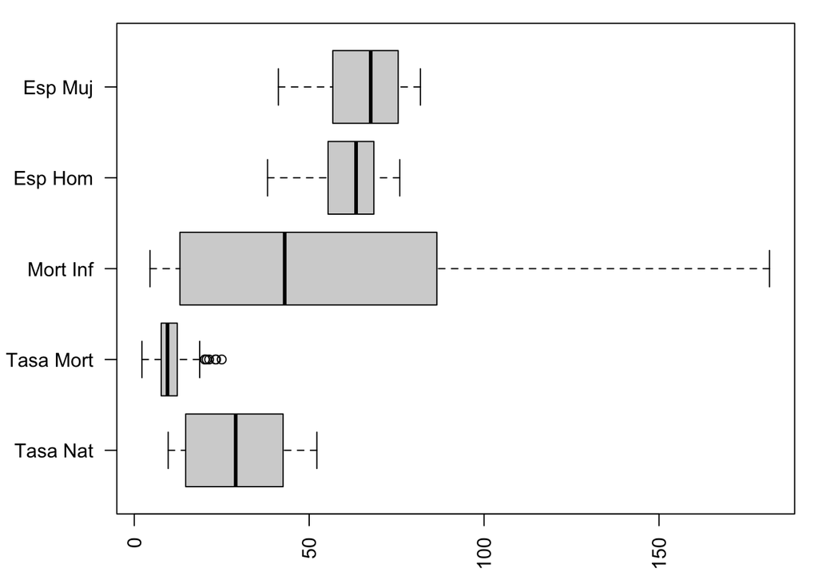

```r
load('../practiques/practica_04/classe/MundoDes.Rdata')
data <- MundoDes
rownames(data) <- substr(data[, 1], 1, 5)
data <- data[, -1]

par(mar = c(3, 5, 1, 1))
boxplot(data[, 1:5], horizontal = TRUE, las = 2)
```

```r
PCA1 <- princomp(data[, 1:5])
summary(PCA1)
```

```
## Importance of components:
##                            Comp.1     Comp.2      Comp.3      Comp.4
## Standard deviation     49.6631000 7.06172925 4.522072696 2.344799529
## Proportion of Variance  0.9695957 0.01960402 0.008038927 0.002161397
## Cumulative Proportion   0.9695957 0.98919969 0.997238616 0.999400013
##                              Comp.5
## Standard deviation     1.2354054430
## Proportion of Variance 0.0005999873
## Cumulative Proportion  1.0000000000
```

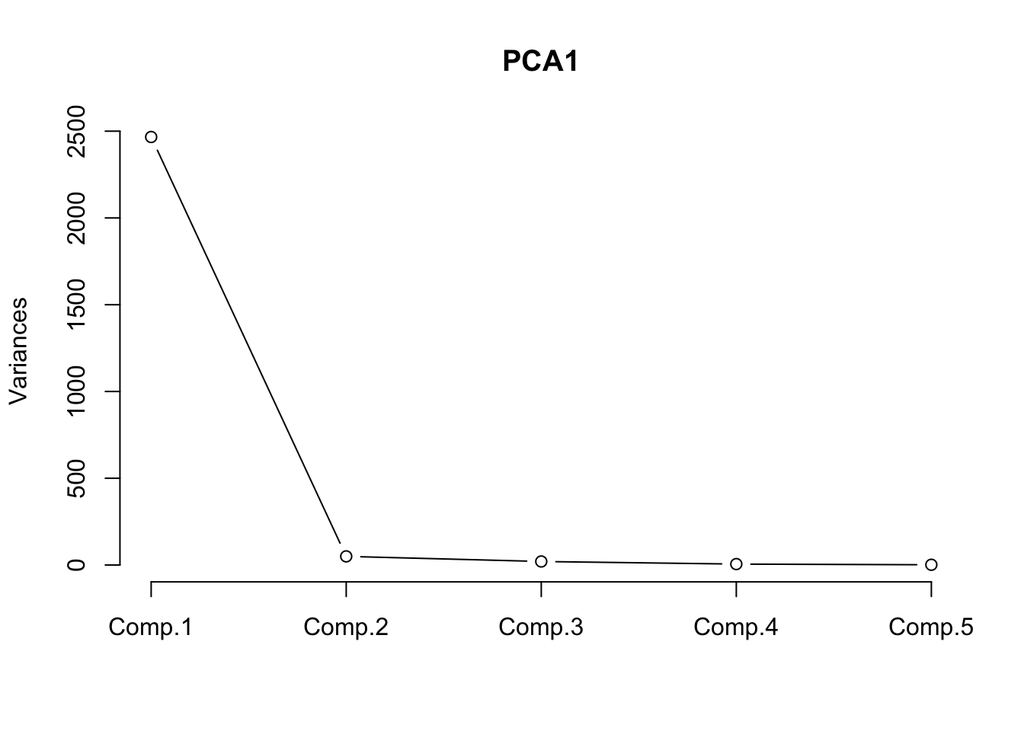

```r
plot(PCA1, type = 'lines')
```

```r
loads <- data.frame(PCA1 = PCA1$loadings[, 1],
                    PCA2 = PCA1$loadings[, 2])
kable(loads, booktabs = T) %>%
  kable_styling(latex_options =c('hold_position', 'striped'))
```

|  | PCA1 | PCA2 |
| --- | --- | --- |
| Tasa Nat | 0.2410146 | 0.9069110 |
| Tasa Mort | 0.0640330 | -0.0982645 |
| Mort Inf | 0.9259430 | -0.3108958 |
| Esp Hom | -0.1846283 | -0.1633528 |
| Esp Muj | -0.2152991 | -0.2109887 |

La component 1 situarà en un extrem els valors alts de mortalitat infantil i de taxa de natalitat així com valors baixos d’esperança de vida, en canvi situarà individus amb esperances de vida molt altes i baixos de taxa de natalitat a l’altre extrem La component 2 situarà a valors positius aquells individus amb altes taxes de natalitat i a valors negatius alts valors en les altres variables.

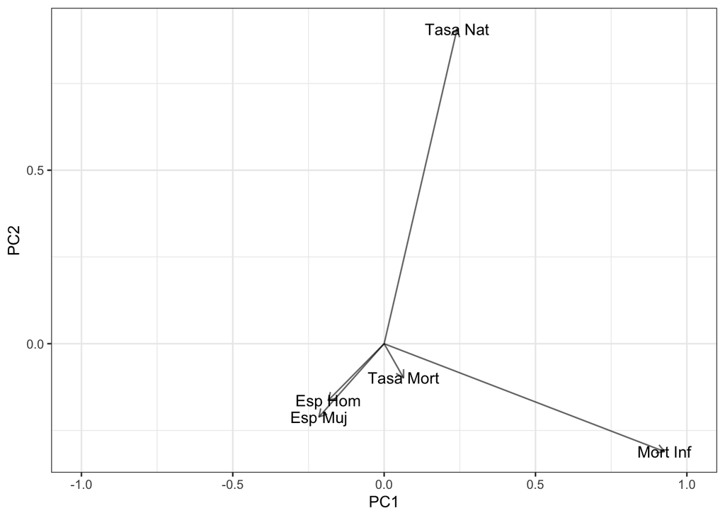

```r
library(ggplot2)

ggplot(loads, aes(PCA1, PCA2)) +
  geom_text(aes(label = rownames(loads)), show.legend = FALSE) +
  geom_segment(data = loads, aes(x = 0, y = 0, xend = PCA1, yend = PCA2),
               arrow = arrow(length = unit(1/2, "picas")), alpha = 0.6) +
  xlab('PC1') +
  ylab('PC2') +
  xlim(c(-1, 1)) +
  theme_bw()
```

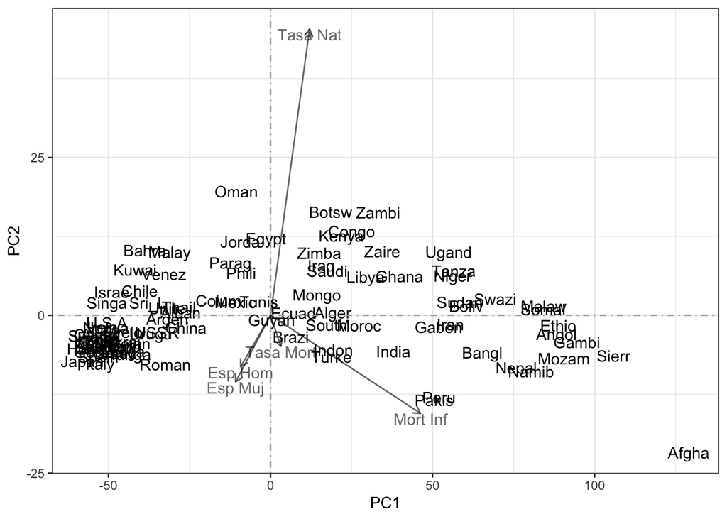

```r
pPCA <- data.frame(PC1 = PCA1$scores[, 1],
                   PC2 = PCA1$scores[, 2])
ggplot(pPCA, aes(PC1, PC2)) +
  geom_text(aes(label = rownames(pPCA)),
            show.legend = FALSE) +
  geom_text(data = loads, aes(50*PCA1, 50*PCA2, label = rownames(loads)),
            alpha = 0.6, hjust = 0.5, vjust = 1) +
  geom_segment(data = loads, aes(x = 0, y = 0, xend = 50*PCA1, yend = 50*PCA2),
               arrow = arrow(length = unit(1/2, "picas")),
               alpha = 0.6) +
  xlab('PC1') +
  ylab('PC2') +
  geom_hline(yintercept = 0, color = 'darkgrey', linetype = 4) +
  geom_vline(xintercept = 0, color = 'darkgrey', linetype = 4) +
  theme_bw()
```

# Anàlisi clúster

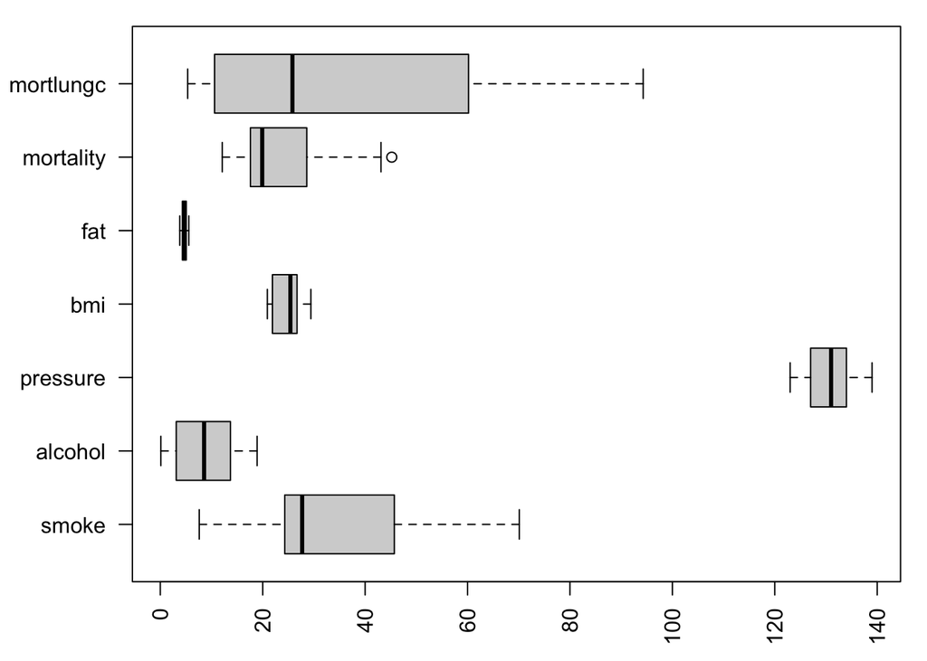

```r
load('../practiques/practica_03/entregar/datoscluster.RData')
data <- datosfinal
remove(datosfinal)
names(data) <- c('country', 'smoke', 'alcohol', 'pressure', 'bmi',
                 'fat', 'mortality', 'mortlungc')
rownames(data) <- substr(data[, 1], 1, 6)
data <- data[, -1]
par(mar = c(3,5,1,1))
boxplot(data, horizontal = TRUE, las = 2)
```

És important fer una anàlisi de la variabilitat de les variables i de cerca d’outliers.

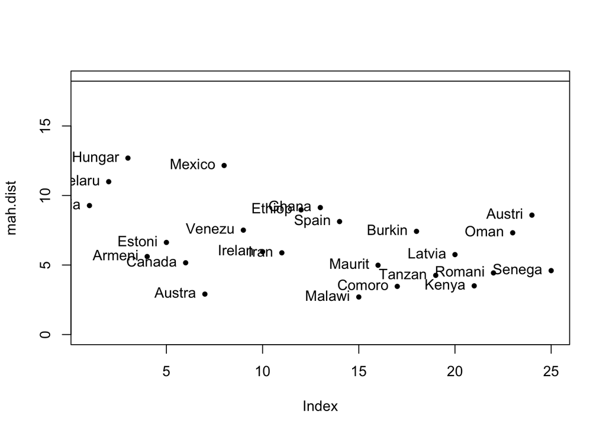

```r
st.data <- data.frame(scale(data))
mah.dist <- mahalanobis(data, apply(data, 2, mean, na.rm = TRUE),
                        cov(data, use = 'na.or.complete'))
k <- dim(data)[2]
mah.lim <- k + 3 * sqrt(k * 2)
plot(mah.dist, pch = 20, ylim = c(0, max(mah.dist, mah.lim, na.rm = TRUE)))
text(mah.dist, labels = rownames(data), pos = 2)
abline(h = mah.lim)
```

## Agrupament jeràrquic

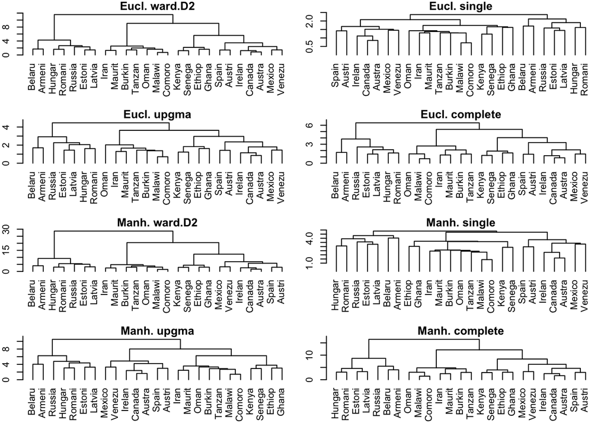

```r
library(cluster)
eu.st.dist <- dist(st.data, method = 'euclidean')
mh.st.dist <- dist(st.data, method = 'manhattan')

# Clusters
eu.st.ward.D2 <- hclust(eu.st.dist, method = 'ward.D2')
eu.st.single <- hclust(eu.st.dist, method = 'single')
eu.st.upgma <- hclust(eu.st.dist, method = 'average')
eu.st.complete <- hclust(eu.st.dist, method = 'complete')

mh.st.ward.D2 <- hclust(mh.st.dist, method = 'ward.D2')
mh.st.single <- hclust(mh.st.dist, method = 'single')
mh.st.upgma <- hclust(mh.st.dist, method = 'average')
mh.st.complete <- hclust(mh.st.dist, method = 'complete')

par(mfrow = c(4, 2), mar = c(1,2,1,1))
plot(eu.st.ward.D2, hang = -1, main = 'Eucl. ward.D2', xlab = '')
plot(eu.st.single, hang = -1, main = 'Eucl. single', xlab = '')
plot(eu.st.upgma, hang = -1, main = 'Eucl. upgma', xlab = '')
plot(eu.st.complete, hang = -1, main = 'Eucl. complete', xlab = '')
plot(mh.st.ward.D2, hang = -1, main = 'Manh. ward.D2', xlab = '')
plot(mh.st.single, hang = -1, main = 'Manh. single', xlab = '')
plot(mh.st.upgma, hang = -1, main = 'Manh. upgma', xlab = '')
plot(mh.st.complete, hang = -1, main = 'Manh. complete', xlab = '')
```

Càlcul de distàncies cofenètiques

```r
tablecoph <- data.frame(Euclidiana =
             rbind(Ward.D2 = cor(eu.st.dist, cophenetic(eu.st.ward.D2)),
                   Sigle = cor(eu.st.dist, cophenetic(eu.st.single)),
                   UPGMA = cor(eu.st.dist, cophenetic(eu.st.upgma)),
                   Complete = cor(eu.st.dist, cophenetic(eu.st.complete))),
           Manhattan =
             rbind(Ward.D2 = cor(mh.st.dist, cophenetic(mh.st.ward.D2)),
                   Sigle = cor(mh.st.dist, cophenetic(mh.st.single)),
                   UPGMA = cor(mh.st.dist, cophenetic(mh.st.upgma)),
                   Complete = cor(mh.st.dist, cophenetic(mh.st.complete))))
kable(tablecoph, booktable = T) %>%
  kable_styling(latex_options =c('hold_position', 'striped'))
```

|  | Euclidiana | Manhattan |
| --- | --- | --- |
| Ward.D2 | 0.8149534 | 0.8080490 |
| Sigle | 0.7874055 | 0.7416868 |
| UPGMA | 0.8255034 | 0.8194381 |
| Complete | 0.8180485 | 0.8110550 |

```r
tablecoph == max(tablecoph)
```

```
##          Euclidiana Manhattan
## Ward.D2       FALSE     FALSE
## Sigle         FALSE     FALSE
## UPGMA          TRUE     FALSE
## Complete      FALSE     FALSE
```

```r
eu.dist <- dist(data, method = 'euclidean')
eu.upgma <- hclust(eu.dist, method = 'average')

cor(eu.st.dist, cophenetic(eu.st.upgma))
```

```
## [1] 0.8255034
```

```r
cor(eu.dist, cophenetic(eu.upgma))
```

```
## [1] 0.8602826
```

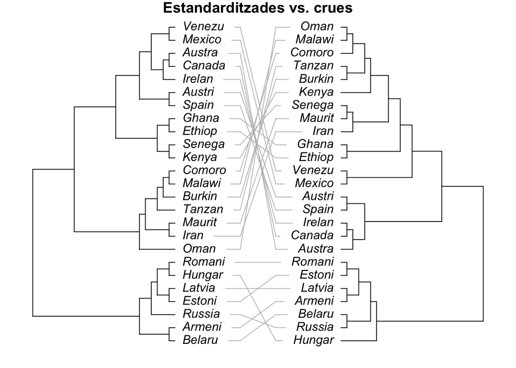

```r
library(ape)
t1 <- as.phylo(eu.st.upgma)
t2 <- as.phylo(eu.upgma)

association <- cbind(t1$tip.label, t2$tip.label)

par(mar = c(1,1,1,1))
cophyloplot(t1, t2, assoc = association, length.line = 2,
            space = 28, gap = 3, col = 'grey')
title('Estandarditzades vs. crues')
```

### Determinem el nombre òptim de grups

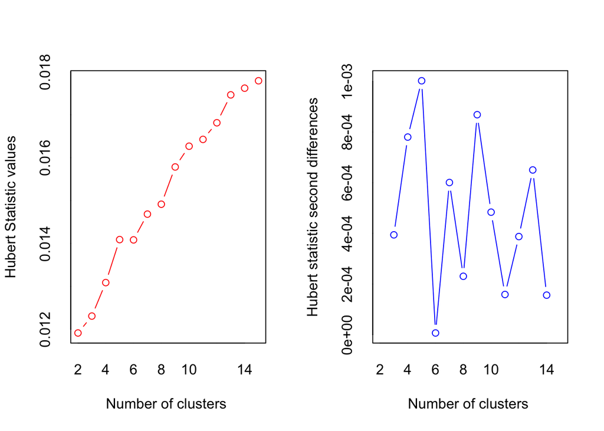

```
## *** : The Hubert index is a graphical method of determining the number of clusters.
##                 In the plot of Hubert index, we seek a significant knee that corresponds to a
##                 significant increase of the value of the measure i.e the significant peak in Hubert
##                 index second differences plot.
##
```

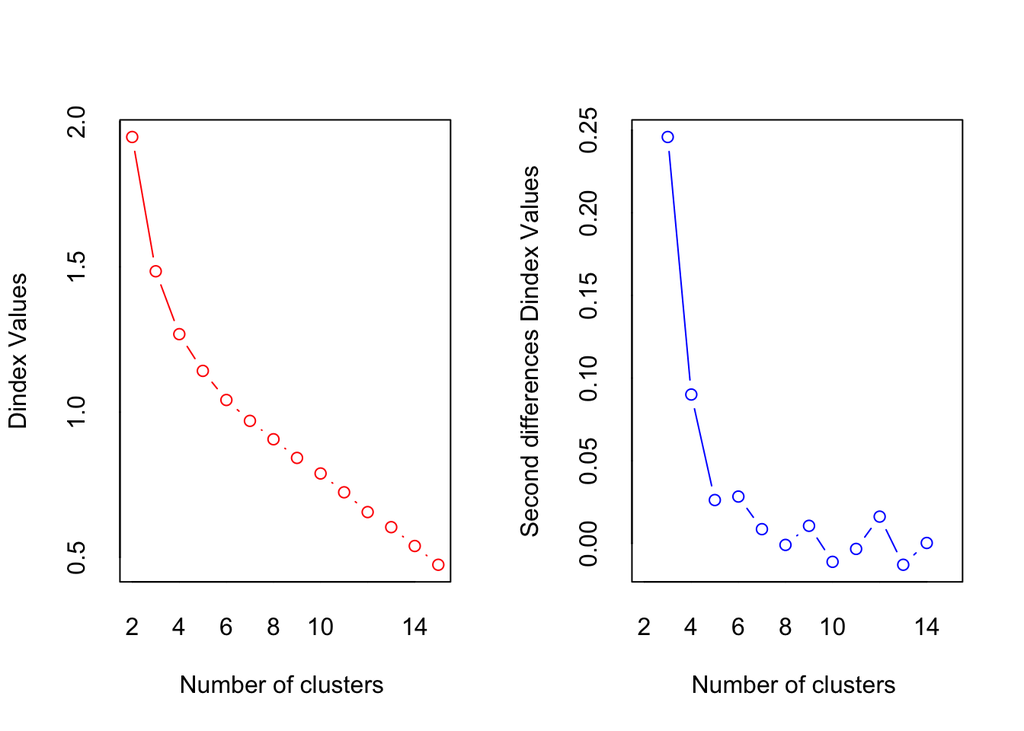

```
## *** : The D index is a graphical method of determining the number of clusters.
##                 In the plot of D index, we seek a significant knee (the significant peak in Dindex
##                 second differences plot) that corresponds to a significant increase of the value of
##                 the measure.
##
## * Among all indices:
## * 1 proposed 2 as the best number of clusters
## * 11 proposed 3 as the best number of clusters
## * 2 proposed 4 as the best number of clusters
## * 1 proposed 5 as the best number of clusters
## * 1 proposed 6 as the best number of clusters
## * 1 proposed 11 as the best number of clusters
## * 6 proposed 15 as the best number of clusters
##
##                    ***** Conclusion *****
##
## * According to the majority rule, the best number of clusters is  3
##
##
```

```r
library(NbClust)
nb.euc.av <- NbClust(st.data, diss = NULL, distance = 'euclidean',
                     method = 'average')
```

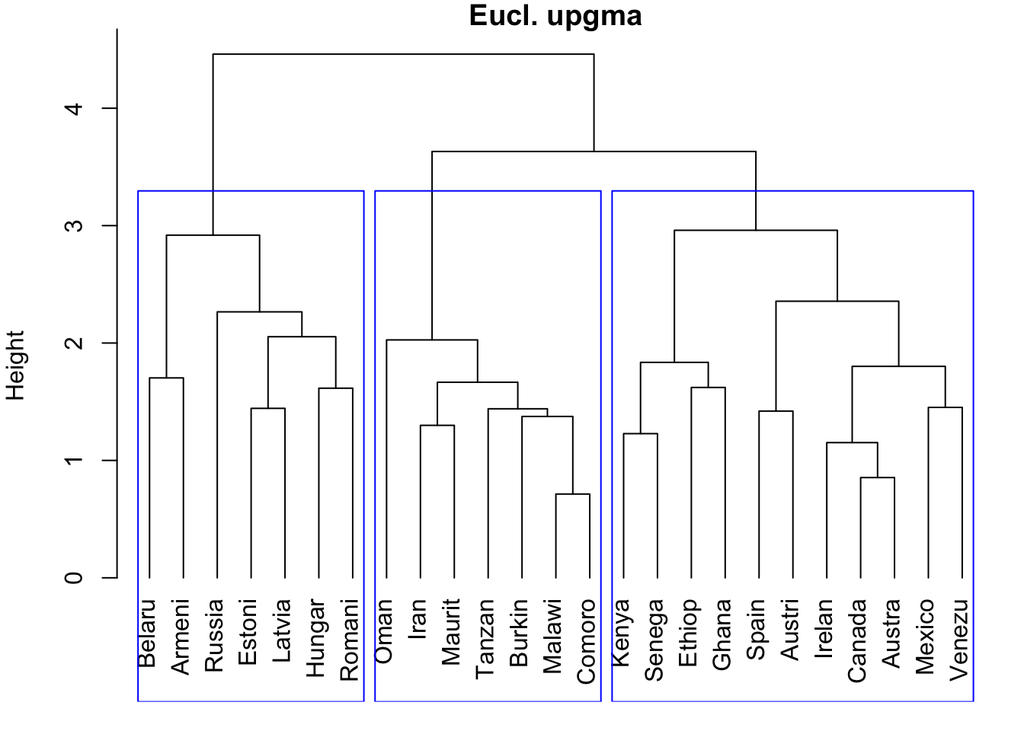

```r
par(mar = c(1, 4, 1, 1))
plot(eu.st.upgma, hang = -1, main = 'Eucl. upgma', xlab = '',
     sub = '')
rect.hclust(eu.st.upgma, k = 3, border = 'blue')
```

En aquest punt triaríem tants grups com estiguen fins a un colze observat en aquesta gràfica, com no se n’observa un d’intens, la transició de tendència més acusada que observem, la tenim a $k = 3$, així que el triarem per a veure els seus agrupaments. Ara aquesta anàlisi ens dona el punt de partida per a elaborar les anàlisis per particions.

## Agrupament per partició

Contrastarem els grups inferits per particions amb els inferits per jeràrquic.

```r
st.data$grup <- nb.euc.av$Best.partition
centr <- matrix(nrow = 3, ncol = 7)
for(g in 1:3){
  centr[g,] <- apply(st.data[which(st.data$grup == g), 1:7], 2, mean)
}
st.km <- kmeans(st.data[, 1:7], centers = centr)
clustt <- table(st.data$grup, st.km$cluster)
kable(clustt, booktabs = T, row.names = T) %>%
  kable_styling(latex_options =c('hold_position', 'striped'))
```

|  | 1 | 2 | 3 |
| --- | --- | --- | --- |
| 1 | 7 | 0 | 0 |
| 2 | 0 | 11 | 0 |
| 3 | 0 | 0 | 7 |

```r
PCA <- princomp(st.data[, 1:7], cor = FALSE)
summary(PCA)
```

```
## Importance of components:
##                           Comp.1    Comp.2    Comp.3     Comp.4     Comp.5
## Standard deviation     1.7719615 1.4056760 0.9447175 0.56374493 0.39597897
## Proportion of Variance 0.4672392 0.2940364 0.1328112 0.04729291 0.02333324
## Cumulative Proportion  0.4672392 0.7612757 0.8940869 0.94137976 0.96471299
##                            Comp.6     Comp.7
## Standard deviation     0.36448213 0.32292640
## Proportion of Variance 0.01976893 0.01551807
## Cumulative Proportion  0.98448193 1.00000000
```

```r
pcatable <- data.frame(round(PCA$loadings[, 1:2], 3))
kable(pcatable, booktabs = T, row.names = T) %>%
  kable_styling(latex_options =c('hold_position', 'striped'))
```

|  | Comp.1 | Comp.2 |
| --- | --- | --- |
| smoke | 0.512 | 0.078 |
| alcohol | 0.499 | -0.162 |
| pressure | -0.197 | 0.177 |
| bmi | -0.011 | -0.665 |
| fat | 0.009 | -0.642 |
| mortality | 0.434 | 0.272 |
| mortlungc | 0.511 | -0.085 |

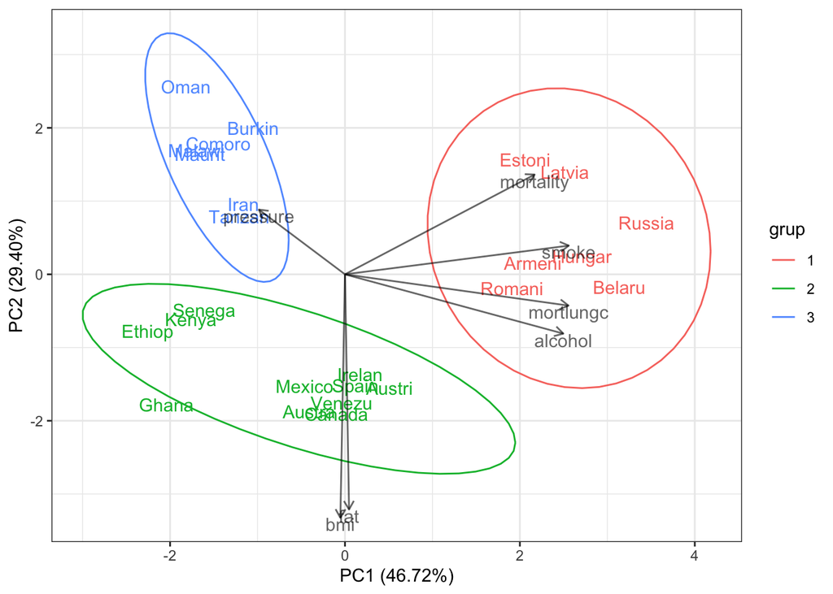

```r
pPCA <- data.frame(PC1 = PCA$scores[, 1],
                   PC2 = PCA$scores[, 2],
                   grup = factor(st.km$cluster))
loads <- data.frame(x = PCA$loadings[, 1],
                    y = PCA$loadings[, 2])

ggplot(pPCA, aes(PC1, PC2)) +
  geom_text(aes(color = grup, label = rownames(pPCA)),
            show.legend = FALSE) +
  stat_ellipse(aes(color = grup)) +
  geom_text(data = loads, aes(5*x, 5*y, label = rownames(loads)),
            alpha = 0.6, hjust = 0.5, vjust = 1) +
  geom_segment(data = loads, aes(x = 0, y = 0, xend = 5*x, yend = 5*y),
               arrow = arrow(length = unit(1/2, "picas")),
               alpha = 0.6) +
  xlab('PC1 (46.72%)') +
  ylab('PC2 (29.40%)') +
  theme_bw()
```

Com veiem hi ha al grup verd una desviació veiem com agrupa amb $k = 4$.

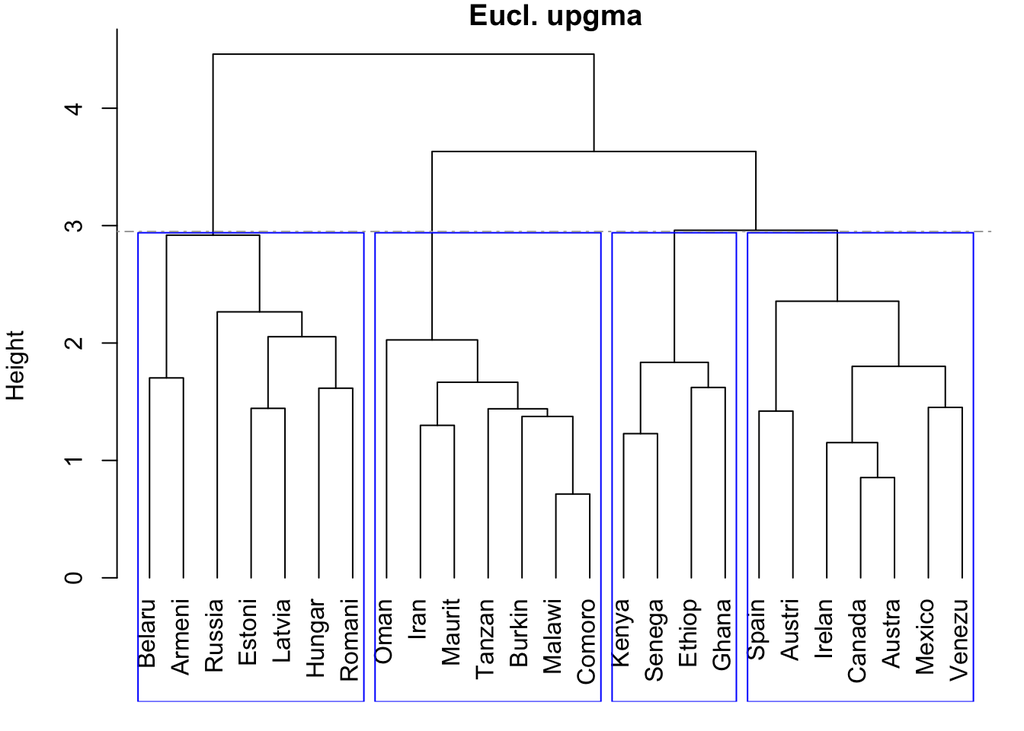

```r
par(mar = c(1, 4, 1, 1))
plot(eu.st.upgma, hang = -1, main = 'Eucl. upgma', xlab = '',
     sub = '')
rect.hclust(eu.st.upgma, k = 4, border = 'blue')
abline(h = 2.95, lty = 4, col = 'darkgrey')
```

```r
centr <- matrix(nrow = 3, ncol = 7)
for(g in 1:3){
  centr[g,] <- apply(st.data[which(st.data$grup == g), 1:7], 2, mean)
}
st.km <- kmeans(st.data[, 1:7], centers = 4)
clustt <- table(st.data$grup, st.km$cluster)
kable(clustt, booktabs = T, row.names = T) %>%
  kable_styling(latex_options =c('hold_position', 'striped'))
```

|  | 1 | 2 | 3 | 4 |
| --- | --- | --- | --- | --- |
| 1 | 0 | 7 | 0 | 0 |
| 2 | 11 | 0 | 0 | 0 |
| 3 | 0 | 0 | 2 | 5 |

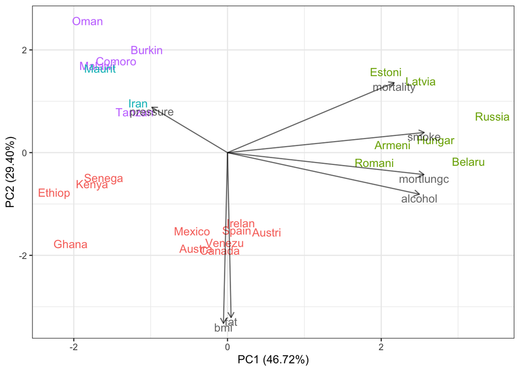

```r
pPCA <- data.frame(PC1 = PCA$scores[, 1],
                   PC2 = PCA$scores[, 2],
                   grup = factor(st.km$cluster))

ggplot(pPCA, aes(PC1, PC2)) +
  geom_text(aes(color = grup, label = rownames(pPCA)),
            show.legend = FALSE) +
  geom_text(data = loads, aes(5*x, 5*y, label = rownames(loads)),
            alpha = 0.6, hjust = 0.5, vjust = 1) +
  geom_segment(data = loads, aes(x = 0, y = 0, xend = 5*x, yend = 5*y),
               arrow = arrow(length = unit(1/2, "picas")),
               alpha = 0.6) +
  xlab('PC1 (46.72%)') +
  ylab('PC2 (29.40%)') +
  theme_bw()
```